# Stelio’s Multilocation Maize Trial: RCBD Field Layout and Line × Tester GCA/SCA

- Show All Code
- Hide All Code
- View Source

Serpentine 5 × 10 field layout, row/column spatial control, and line x tester GCA/SCA from `data/multilocation.csv`

Author

Fausto Rodriguez Zapata

Published

June 4, 2026

**Source code & data:** https://github.com/faustovrz/gcamoz

**Note**

This notebook documents the experimental design of Stelio’s real file, `data/multilocation.csv`, **and** runs the full combining-ability analysis directly on it. The real file carries the **line x tester pedigree** (`Female`, `Male`, `Female x Male`) and a **replicated commercial check**, in addition to the plot-level phenotypes. It describes a **multilocation field trial** — an RCBD with a 5 × 10 serpentine plot layout per replication: 49 line x tester hybrids plus one repeated check, evaluated in 3 replications per environment across 5 environments. The earlier `gca_calculation.qmd` ran the same pipeline on *simulated* RCBD data; here the EDA, arithmetic GCA/SCA, mixed-model variance components, breeding values, and heritabilities are all computed on Stelio’s actual grain yield (`GY`) across all five environments.

# 1 Theoretical Foundation & Experimental Setup

Before fitting a genetic model, we must separate three ideas that are easy to mix together:

1. The **genetic material** being evaluated.
2. The **experimental allocation / field layout** used to control local variation.
3. The **phenotypic model** used to analyze the traits.

The file contains plot-level phenotypes from a multilocation maize trial **and** the pedigree key that maps each genotype to its female and male parent. This means the field-design structure and a line x tester GCA/SCA analysis can both be set up directly from a single file — no external metadata table is needed anymore.

## 1.1 Breeding Scheme (Line x Tester)

Stelio’s research focuses on the genetic architecture of low-phosphorus use efficiency in maize. The 49 hybrid genotypes represent a **Factorial Mating Design**, often referred to as a **Line x Tester** or **North Carolina Design II**.

Two distinct parental sets are crossed:

- **Female parents / lines:** 7 CIMMYT CML tropical donor founders.
- **Male parents / testers:** 7 Mozambique IIAM tester lines (`EN` series; the NCDII `MOZL` donors).
- **Hybrid families:** all 7 x 7 = **49 F1 hybrid combinations**.

In addition to the 49 hybrids, the trial includes a **repeated commercial check** (`NAMULONGUE`) so that environments and replications can be calibrated against a known standard.

## 1.2 Genetic Material Planted in the Field

The data now identify each plot with both a numeric genotype code (`GEN`) and the explicit pedigree (`Female`, `Male`, `Female x Male`):

- `GEN` has **50 levels**: `0` for the check and `1`–`49` for the hybrids.
- `GEN = 0` is the **`NAMULONGUE` check** (`Female = Check`, `Male = Check`).
- `GEN = 1`–`49` are the line x tester hybrids.

The real founder identifiers (which replace the earlier `MOZ1`–`MOZ7` placeholders) are:

| Parent set | Role in factorial design | Real IDs in the file |
| --- | --- | --- |
| CIMMYT CML donors | Female / tropical donor lines | `CML364`, `CML366`, `CML434`, `CML435`, `CML439`, `CML530`, `CML532` |
| Mozambique testers | Male local tester lines (IIAM IDs) | `EN17`, `EN20`, `EN21`, `EN25`, `EN31`, `EN32`, `EN64` |
| Commercial check | Standard reference entry | `NAMULONGUE` (`GEN = 0`) |

The Mozambique testers carry their **IIAM donor IDs** — `EN17`, `EN20`, `EN21`, `EN25`, `EN31`, `EN32`, `EN64` — which are the canonical identifiers used throughout this analysis. The `MOZL3`–`MOZL10` labels (the “NCDII ID” in the donor records) are a **legacy, ad hoc identifier** carried over from an earlier stage of the project; they are kept here only as a cross-reference to older files and field books, and name the same seven testers. The CIMMYT line `CML530` is part of the female set; the earlier draft had incorrectly listed `CML440`.

The full pedigrees of the seven IIAM tester donors:

| IIAM ID | NCDII ID | Pedigree |
| --- | --- | --- |
| `EN17` | `MOZL3` | `(ZM421-6-4-1-2-2-2-2-B/CML491-1)-10-1-1-1-1-1-B` |
| `EN20` | `MOZL5` | `(ZM421-6-4-1-2-2-2-2-B/CML491-1)-34-1-1-1-1-1-B` |
| `EN21` | `MOZL6` | `(ZM421-6-4-1-2-2-2-2-B/CML491-1)-36-1-1-1-1-1-B` |
| `EN25` | `MOZL7` | `(ZM421-18-8-1-3-1-3-1-3-B/CLRCY034-1)-29-1-1-1-1-1-B` |
| `EN31` | `MOZL8` | `(ZM421-18-8-1-3-1-3-1-3-B/CLRCY034-1)-13-1-1-1-1-1-B` |
| `EN32` | `MOZL9` | `(ZM421-18-8-1-3-1-3-1-3-B/CLRCY034-1)-14-1-1-1-1-1-B` |
| `EN64` | `MOZL10` | `(MATUBASG-26-1-3-3-1-2-5-1-B/CML539-1)-63-1-1-1-1-1-B` |

# 2 R Setup and Data Import

```r
library(tidyverse)
library(sommer)
library(knitr)
library(kableExtra)

raw_data <- read_csv("data/multilocation.csv", show_col_types = FALSE) %>%
  mutate(
    file_order = row_number(),                      # as-entered plot order
    ENV    = factor(env),
    REP    = factor(rep, levels = c("I", "II", "III")),
    GEN    = factor(gen, levels = as.character(0:49)),
    Female = factor(female,
                    levels = c("Check",
                               "CML364", "CML366", "CML434", "CML435",
                               "CML439", "CML530", "CML532")),
    # Males carry their IIAM donor IDs (NCDII MOZL3/5/6/7/8/9/10 = EN17/20/21/25/31/32/64).
    Male   = factor(male,
                    levels = c("Check",
                               "EN17", "EN20", "EN21", "EN25",
                               "EN31", "EN32", "EN64")),
    yield  = GY
  )

# Field coordinates from the serpentine planting order (Stelio's procedure: first plot
# top-left, 5 columns x 10 rows, snaking down). ENTRY is the planting order and increases
# down the file within each ENV x REP, so we index plot_order by file order rather than the
# `entry` column, which has blank entries in two reps (CHOKWE STS III, NHACOONGO II) that
# would misplace plots; the physical row sequence is intact.
field <- raw_data %>%
  group_by(ENV, REP) %>%
  arrange(file_order, .by_group = TRUE) %>%
  mutate(
    plot_order = row_number(),                      # 1 .. 50 within each env x rep
    field_row  = ceiling(plot_order / 5),           # 1 (top) .. 10 (bottom)
    pos_in_row = ((plot_order - 1) %% 5) + 1,
    field_col  = if_else(field_row %% 2 == 1, pos_in_row, 6L - pos_in_row)  # serpentine
  ) %>%
  ungroup()

# Hybrids-only analysis frame (the check, GEN = 0, is held out of the line x
# tester decomposition). `row`/`col` are the real field positions of each plot.
hybrids <- field %>%
  filter(GEN != "0") %>%
  transmute(
    env    = droplevels(ENV),
    rep    = REP,
    row    = factor(field_row, levels = 1:10),
    col    = factor(field_col, levels = 1:5),
    female = droplevels(Female),
    male   = droplevels(Male),
    cross  = factor(hybrid),
    yield  = yield
  )
```

## 2.1 Entries Planted in the Field (including checks)

The table below is the complete entry key actually planted, generated directly from the file. The check is entry `GEN = 0`; the 49 hybrids follow.

```r
entry_key <- raw_data %>%
  distinct(GEN, Female, Male, hybrid) %>%
  arrange(GEN) %>%
  rename(cross = hybrid)

kable(entry_key, caption = "All 50 entries planted: 1 check (GEN = 0) + 49 line x tester hybrids") %>%
  kable_styling(bootstrap_options = c("striped", "hover", "condensed")) %>%
  scroll_box(height = "420px")
```

All 50 entries planted: 1 check (GEN = 0) + 49 line x tester hybrids

| GEN | Female | Male | cross |
| --- | --- | --- | --- |
| 0 | Check | Check | Check |
| 1 | CML364 | EN17 | CML364xEN17 |
| 2 | CML366 | EN17 | CML366xEN17 |
| 3 | CML434 | EN17 | CML434xEN17 |
| 4 | CML435 | EN17 | CML435xEN17 |
| 5 | CML439 | EN17 | CML439xEN17 |
| 6 | CML530 | EN17 | CML530xEN17 |
| 7 | CML532 | EN17 | CML532xEN17 |
| 8 | CML364 | EN20 | CML364xEN20 |
| 9 | CML366 | EN20 | CML366xEN20 |
| 10 | CML434 | EN20 | CML434xEN20 |
| 11 | CML435 | EN20 | CML435xEN20 |
| 12 | CML439 | EN20 | CML439xEN20 |
| 13 | CML530 | EN20 | CML530xEN20 |
| 14 | CML532 | EN20 | CML532xEN20 |
| 15 | CML364 | EN21 | CML364xEN21 |
| 16 | CML366 | EN21 | CML366xEN21 |
| 17 | CML434 | EN21 | CML434xEN21 |
| 18 | CML435 | EN21 | CML435xEN21 |
| 19 | CML439 | EN21 | CML439xEN21 |
| 20 | CML530 | EN21 | CML530xEN21 |
| 21 | CML532 | EN21 | CML532xEN21 |
| 22 | CML364 | EN25 | CML364xEN25 |
| 23 | CML366 | EN25 | CML366xEN25 |
| 24 | CML434 | EN25 | CML434xEN25 |
| 25 | CML435 | EN25 | CML435xEN25 |
| 26 | CML439 | EN25 | CML439xEN25 |
| 27 | CML530 | EN25 | CML530xEN25 |
| 28 | CML532 | EN25 | CML532xEN25 |
| 29 | CML364 | EN31 | CML364xEN31 |
| 30 | CML366 | EN31 | CML366xEN31 |
| 31 | CML434 | EN31 | CML434xEN31 |
| 32 | CML435 | EN31 | CML435xEN31 |
| 33 | CML439 | EN31 | CML439xEN31 |
| 34 | CML530 | EN31 | CML530xEN31 |
| 35 | CML532 | EN31 | CML532xEN31 |
| 36 | CML364 | EN32 | CML364xEN32 |
| 37 | CML366 | EN32 | CML366xEN32 |
| 38 | CML434 | EN32 | CML434xEN32 |
| 39 | CML435 | EN32 | CML435xEN32 |
| 40 | CML439 | EN32 | CML439xEN32 |
| 41 | CML530 | EN32 | CML530xEN32 |
| 42 | CML532 | EN32 | CML532xEN32 |
| 43 | CML364 | EN64 | CML364xEN64 |
| 44 | CML366 | EN64 | CML366xEN64 |
| 45 | CML434 | EN64 | CML434xEN64 |
| 46 | CML435 | EN64 | CML435xEN64 |
| 47 | CML439 | EN64 | CML439xEN64 |
| 48 | CML530 | EN64 | CML530xEN64 |
| 49 | CML532 | EN64 | CML532xEN64 |

## 2.2 Real Factorial Mating Grid (7 x 7)

Each cell is the genotype code `GEN` assigned to that female x male cross. The full grid is present, with no missing or duplicated cells.

```r
mating_grid <- raw_data %>%
  filter(GEN != "0") %>%
  distinct(Female, Male, GEN) %>%
  droplevels() %>%
  arrange(Female, Male) %>%
  pivot_wider(names_from = Male, values_from = GEN)

kable(mating_grid, caption = "Real 7 x 7 line x tester grid; cells show the GEN code for each cross") %>%
  kable_styling(bootstrap_options = c("striped", "hover", "condensed"))
```

Real 7 x 7 line x tester grid; cells show the GEN code for each cross

| Female | EN17 | EN20 | EN21 | EN25 | EN31 | EN32 | EN64 |
| --- | --- | --- | --- | --- | --- | --- | --- |
| CML364 | 1 | 8 | 15 | 22 | 29 | 36 | 43 |
| CML366 | 2 | 9 | 16 | 23 | 30 | 37 | 44 |
| CML434 | 3 | 10 | 17 | 24 | 31 | 38 | 45 |
| CML435 | 4 | 11 | 18 | 25 | 32 | 39 | 46 |
| CML439 | 5 | 12 | 19 | 26 | 33 | 40 | 47 |
| CML530 | 6 | 13 | 20 | 27 | 34 | 41 | 48 |
| CML532 | 7 | 14 | 21 | 28 | 35 | 42 | 49 |

# 3 Experimental Design

> The field design is the actual plot allocation used to evaluate the genotypes produced by the 7 x 7 line-by-tester crossing design, together with the repeated check.

Stelio’s trial is a **field trial**: each plot is a full row of maize. Within every replication the 50 entries (49 hybrids + 1 check) are laid out on a **5-column × 10-row grid** and sown in **serpentine order** — first plot top-left, snaking down (see the field-layout map below).

The **49 hybrids are randomized within each replication**, and the `NAMULONGUE` check travels along the planting sequence. Because the hybrids are completely randomized within a replication — with **no separately randomized incomplete blocks** — the trial is analyzed as a **randomized complete block design (RCBD)**, with the replication as the complete block. To guard against field gradients across the 5 × 10 grid, the plot **row** and **column** (recovered from the serpentine planting order) are added as nested spatial terms — a light spatial correction layered on top of the RCBD.

## 3.1 Locations / Environments

The trial spans **four physical locations** (`loc`) run under two **phosphorus treatments**, giving **five environments** in the `ENV` column (`env` = location + P-treatment code): three are **P-stress** and two are **optimal**. The applied P, recovered per plot as `GY / PUE`, is exactly 10 kg/ha (stress) at the three stress environments and 50 kg/ha at the two optimal:

| `ENV` | Location (`loc`) | Treatment | P input (kg/ha) |
| --- | --- | --- | --- |
| `CHOKWE OPT` | Chokwe | Optimal | 50 |
| `CHOKWE STS` | Chokwe | Stress | 10 |
| `MANIQUENIQ OPT` | Maniquenique | Optimal | 50 |
| `NHACOONGO STS` | Nhacoongo | Stress | 10 |
| `SUSSUNDENGA STS` | Sussundenga | Stress | 10 |

## 3.2 Field Layout Within Each Location

Within each location and replication:

- all 49 hybrids appear **once**, plus **one** check plot — 50 plots total;
- the 50 plots occupy a **5 × 10 field grid** (5 columns × 10 rows);
- each replication is therefore a complete replicate of the 50 entries (one complete block).

Across the trial:

- **Environments (`ENV`)**: 5.
- **Replications (`REP`)**: `I`, `II`, and `III` within each environment.
- **Entries (`GEN`)**: 49 hybrids + 1 check = 50 per replication.
- **Traits**: grain yield, yield per plant, plant number, ear weight, grain weight, plant height, culm diameter, flowering dates, dry matter mass, and root weight.

This is a standard RCBD: each replication is one complete block of 50 plots. The only refinement we add for analysis is the plot **row** and **column** within each replication (from the 5 × 10 serpentine), fitted as random spatial terms so that systematic field trends are not left in the residual.

# 4 Design Diagnostics

## 4.1 Basic Dimensions

```r
design_summary <- raw_data %>%
  summarize(
    rows          = n(),
    environments  = n_distinct(ENV),
    replications  = n_distinct(REP),
    total_entries = n_distinct(GEN),
    hybrids       = n_distinct(GEN[GEN != "0"]),
    checks        = n_distinct(GEN[GEN == "0"])
  )

kable(design_summary, caption = "Basic dimensions of Stelio's multilocation dataset") %>%
  kable_styling(bootstrap_options = c("striped", "hover", "condensed"))
```

Basic dimensions of Stelio's multilocation dataset

| rows | environments | replications | total_entries | hybrids | checks |
| --- | --- | --- | --- | --- | --- |
| 750 | 5 | 3 | 50 | 49 | 1 |

## 4.2 Replication Completeness

Every environment-by-replication now holds exactly 50 plots (49 hybrids + 1 check), with no duplicated entries.

```r
rep_summary <- raw_data %>%
  count(ENV, REP, name = "observed_rows") %>%
  left_join(
    raw_data %>%
      summarize(unique_entries = n_distinct(GEN), .by = c(ENV, REP)),
    by = c("ENV", "REP")
  ) %>%
  mutate(
    expected_rows = 50,
    difference    = observed_rows - expected_rows
  )

kable(rep_summary, caption = "Observed rows and unique entries per environment-by-replication") %>%
  kable_styling(bootstrap_options = c("striped", "hover", "condensed"))
```

Observed rows and unique entries per environment-by-replication

| ENV | REP | observed_rows | unique_entries | expected_rows | difference |
| --- | --- | --- | --- | --- | --- |
| CHOKWE OPT | I | 50 | 50 | 50 | 0 |
| CHOKWE OPT | II | 50 | 50 | 50 | 0 |
| CHOKWE OPT | III | 50 | 50 | 50 | 0 |
| CHOKWE STS | I | 50 | 50 | 50 | 0 |
| CHOKWE STS | II | 50 | 50 | 50 | 0 |
| CHOKWE STS | III | 50 | 50 | 50 | 0 |
| MANIQUENIQ OPT | I | 50 | 50 | 50 | 0 |
| MANIQUENIQ OPT | II | 50 | 50 | 50 | 0 |
| MANIQUENIQ OPT | III | 50 | 50 | 50 | 0 |
| NHACOONGO STS | I | 50 | 50 | 50 | 0 |
| NHACOONGO STS | II | 50 | 50 | 50 | 0 |
| NHACOONGO STS | III | 50 | 50 | 50 | 0 |
| SUSSUNDENGA STS | I | 50 | 50 | 50 | 0 |
| SUSSUNDENGA STS | II | 50 | 50 | 50 | 0 |
| SUSSUNDENGA STS | III | 50 | 50 | 50 | 0 |

## 4.3 Cross and Check Replication Balance

```r
hybrid_balance <- raw_data %>%
  filter(GEN != "0") %>%
  count(hybrid, name = "plots") %>%
  count(plots, name = "n_crosses")

check_balance <- raw_data %>%
  filter(GEN == "0") %>%
  count(ENV, REP, name = "check_plots")

kable(hybrid_balance, caption = "Every hybrid cross is observed in the same number of plots") %>%
  kable_styling(bootstrap_options = c("striped", "hover", "condensed"))
```

Every hybrid cross is observed in the same number of plots

| plots | n_crosses |
| --- | --- |
| 15 | 49 |

```r
kable(check_balance, caption = "The NAMULONGUE check appears once per environment-by-replication") %>%
  kable_styling(bootstrap_options = c("striped", "hover", "condensed"))
```

The NAMULONGUE check appears once per environment-by-replication

| ENV | REP | check_plots |
| --- | --- | --- |
| CHOKWE OPT | I | 1 |
| CHOKWE OPT | II | 1 |
| CHOKWE OPT | III | 1 |
| CHOKWE STS | I | 1 |
| CHOKWE STS | II | 1 |
| CHOKWE STS | III | 1 |
| MANIQUENIQ OPT | I | 1 |
| MANIQUENIQ OPT | II | 1 |
| MANIQUENIQ OPT | III | 1 |
| NHACOONGO STS | I | 1 |
| NHACOONGO STS | II | 1 |
| NHACOONGO STS | III | 1 |
| SUSSUNDENGA STS | I | 1 |
| SUSSUNDENGA STS | II | 1 |
| SUSSUNDENGA STS | III | 1 |

**Note**

**What changed from the earlier draft.** An earlier version of this notebook reported 597 rows and a suspicious “duplicated `GEN = 49`” in three environments, plus a `NHACOONGO` that looked one replicate short. That was an artifact of the check being mislabeled as a second `GEN = 49` and missing from `NHACOONGO`. In the corrected file the check is its own entry (`GEN = 0`, `NAMULONGUE`), present once per environment-by-replication, giving a balanced **750 rows** (49 hybrids × 15 + 15 checks, across 5 environments × 3 reps).

# 5 Field Coordinates from the Planting Order

The CSV has no explicit row/column columns, but the `ENTRY` column records Stelio’s planting order, and the field was sown in a fixed serpentine: first plot top-left, then across a **5-column × 10-row** grid, snaking down. From that order we recover each plot’s field **row** (1–10) and **column** (1–5) — computed once in the `field` frame in the setup chunk. The grid is complete in every environment-by-replication:

```r
grid_check <- field %>%
  summarize(
    rows  = n_distinct(field_row),
    cols  = n_distinct(field_col),
    plots = n(),
    .by   = c(ENV, REP)
  ) %>%
  arrange(ENV, REP)

kable(grid_check, caption = "Every environment-by-replication fills a complete 5-column × 10-row field grid (50 plots)") %>%
  kable_styling(bootstrap_options = c("striped", "hover", "condensed")) %>%
  scroll_box(height = "300px")
```

Every environment-by-replication fills a complete 5-column × 10-row field grid (50 plots)

| ENV | REP | rows | cols | plots |
| --- | --- | --- | --- | --- |
| CHOKWE OPT | I | 10 | 5 | 50 |
| CHOKWE OPT | II | 10 | 5 | 50 |
| CHOKWE OPT | III | 10 | 5 | 50 |
| CHOKWE STS | I | 10 | 5 | 50 |
| CHOKWE STS | II | 10 | 5 | 50 |
| CHOKWE STS | III | 10 | 5 | 50 |
| MANIQUENIQ OPT | I | 10 | 5 | 50 |
| MANIQUENIQ OPT | II | 10 | 5 | 50 |
| MANIQUENIQ OPT | III | 10 | 5 | 50 |
| NHACOONGO STS | I | 10 | 5 | 50 |
| NHACOONGO STS | II | 10 | 5 | 50 |
| NHACOONGO STS | III | 10 | 5 | 50 |
| SUSSUNDENGA STS | I | 10 | 5 | 50 |
| SUSSUNDENGA STS | II | 10 | 5 | 50 |
| SUSSUNDENGA STS | III | 10 | 5 | 50 |

These row and column coordinates are used as nested spatial terms (`env:rep:row`, `env:rep:col`) in the mixed model, so that field gradients across the 5 × 10 grid are absorbed rather than left in the residual.

# 6 Field Layout: Serpentine Planting Map

Each replication is sown as a **5-column × 10-row** field block (5 × 10 = 50 plots) in **serpentine (boustrophedon) order** — Stelio’s planting procedure: the first entry is placed in the **top-left corner**, the first row is filled left-to-right, the next row right-to-left, and so on down the block. Consecutively-planted plots are therefore physical neighbours.

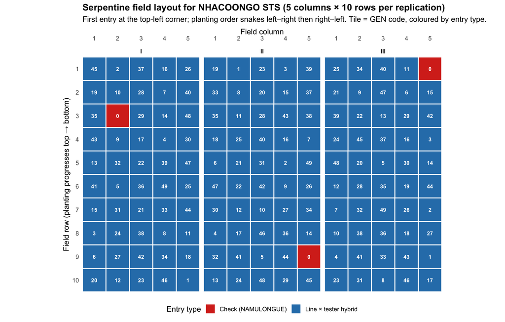

```r
field_layout <- field %>%
  filter(ENV == "NHACOONGO STS") %>%   # field_row / field_col come from the setup chunk
  mutate(entry_type = if_else(GEN == "0", "Check (NAMULONGUE)", "Line × tester hybrid"))

entry_palette <- c(
  "Line × tester hybrid" = "#2C7FB8",
  "Check (NAMULONGUE)"        = "#D7301F"
)

ggplot(field_layout, aes(x = field_col, y = field_row, fill = entry_type)) +
  geom_tile(color = "white", linewidth = 0.7) +
  geom_text(aes(label = GEN), size = 3, fontface = "bold", color = "white") +
  facet_wrap(~ REP, nrow = 1) +
  scale_fill_manual(values = entry_palette, name = "Entry type") +
  scale_x_continuous(breaks = 1:5, position = "top", expand = c(0, 0)) +
  scale_y_reverse(breaks = 1:10, expand = c(0, 0)) +
  coord_equal() +
  labs(
    title    = "Serpentine field layout for NHACOONGO STS (5 columns × 10 rows per replication)",
    subtitle = "First entry at the top-left corner; planting order snakes left–right then right–left. Tile = GEN code, coloured by entry type.",
    x = "Field column",
    y = "Field row (planting progresses top → bottom)"
  ) +
  theme_minimal(base_size = 12) +
  theme(
    panel.grid      = element_blank(),
    strip.text      = element_text(face = "bold"),
    plot.title      = element_text(face = "bold"),
    legend.position = "bottom"
  )
```

**Note**

This map is the field’s planting layout: `ENTRY` is the sowing order and the 5 × 10 serpentine is Stelio’s planting procedure (first plot top-left, snaking down). The field **row** and **column** read off this map are exactly the coordinates fed to the `env:rep:row` and `env:rep:col` spatial terms in the mixed model below.

# 7 Is the Design an Alpha-Lattice? A Co-occurrence Test

Stelio originally described the trial as an **alpha (incomplete-block) design**. Before adopting the RCBD model below, we test that claim directly against the data. The test rests on a single defining property of a resolvable **α(0,1)-lattice** (Patterson & Williams, 1976): within the replications of one environment, **every pair of genotypes shares an incomplete block at most once**. An α-design is, in effect, *just* a restriction on co-occurrence — so if the design is a genuine α-lattice, a census of how often each genotype pair lands in the same block must produce only the counts **0 and 1**, with no pair ever co-occurring twice.

In a 5 × 10 layout the only contiguous grouping that yields an incomplete block of $k = 5$ with $s = 10$ blocks per replication (so $v = s \cdot k = 50$) is the **field row**. We therefore treat each field row as a *putative* incomplete block and count co-occurrences for all $\binom{50}{2} = 1225$ genotype pairs (the check `GEN = 0` included), within the 3 replications of each environment. Two reference distributions frame the result:

- **Ideal α(0,1) lattice** (deterministic): the within-block pairs number $r \cdot s \cdot \binom{k}{2} = 3 \cdot 10 \cdot 10 = 300$, so exactly **300 pairs concur once and 925 concur zero times** — two bars, nothing at 2+.
- **Random RCBD** (simulated): 50 genotypes thrown at random into the 10 rows, 1000 times — the binomial-like spread expected when there is *no* incomplete-block structure.

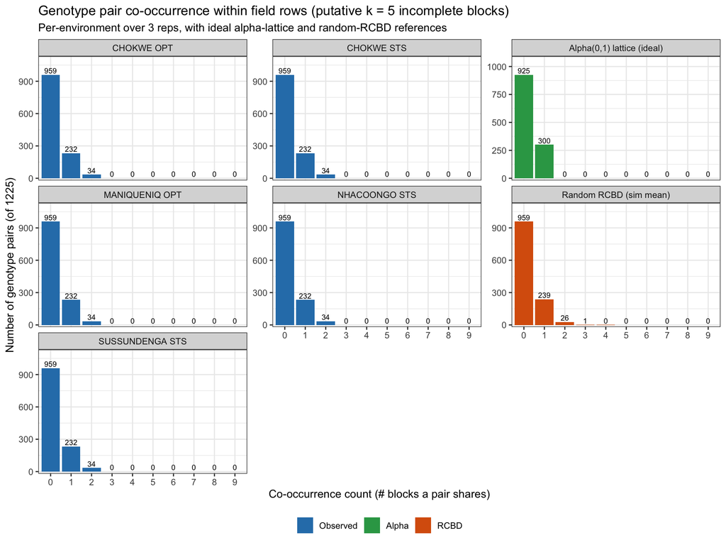

```r
set.seed(20260616)

maxc <- 9   # display range for co-occurrence counts

# Putative incomplete block = field row (5 contiguous plots, s = 10 per rep).
blk  <- field %>% mutate(gen = as.integer(as.character(GEN)))
gens <- sort(unique(blk$gen))                       # 0..49 -> 50 genotypes
all_keys <- combn(gens, 2, FUN = function(p) paste(p[1], p[2], sep = "_"))

# co-occurrence count for every pair, given the columns that define a block
cooc_counts <- function(data, block_cols) {
  cnt <- data %>%
    group_by(across(all_of(block_cols))) %>%
    summarise(pk = list(combn(sort(gen), 2,
                              FUN = function(p) paste(p[1], p[2], sep = "_"))),
              .groups = "drop") %>%
    tidyr::unnest(pk) %>%
    count(pk, name = "cooc")
  tibble(pk = all_keys) %>%
    left_join(cnt, by = "pk") %>%
    mutate(cooc = tidyr::replace_na(cooc, 0L)) %>%
    pull(cooc)
}

dist_row <- function(counts, panel, type)
  tibble(count = 0:maxc,
         pairs = as.integer(table(factor(counts, levels = 0:maxc))),
         panel = panel, type = type)

envs <- levels(droplevels(field$ENV))

# Observed: per environment, across its 3 reps, block = field row
obs_df <- bind_rows(lapply(envs, function(e)
  dist_row(cooc_counts(filter(blk, ENV == e), c("REP", "field_row")),
           panel = e, type = "Observed")))

# Reference 1 — random-RCBD expectation: permute 50 genotypes into 10 rows, 1000 sims
n_sim <- 1000
sim_block <- expand.grid(REP = 1:3, field_row = 1:10, slot = 1:5)
sim_acc <- numeric(maxc + 1)
for (s in seq_len(n_sim)) {
  d <- sim_block
  d$gen <- unlist(lapply(1:3, function(r) sample(gens, 50)))
  cc <- cooc_counts(d, c("REP", "field_row"))
  sim_acc <- sim_acc + as.integer(table(factor(cc, levels = 0:maxc)))
}
sim_df <- tibble(count = 0:maxc, pairs = sim_acc / n_sim,
                 panel = "Random RCBD (sim mean)", type = "RCBD")

# Reference 2 — ideal alpha(0,1) lattice (deterministic): 300 pairs at 1, 925 at 0
alpha_pairs <- numeric(maxc + 1); alpha_pairs[1] <- 925; alpha_pairs[2] <- 300
alpha_df <- tibble(count = 0:maxc, pairs = alpha_pairs,
                   panel = "Alpha(0,1) lattice (ideal)", type = "Alpha")

# 3-column grid: the 5 environments fill columns 1-2 (row-major), and column 3 holds the
# two design references — Alpha(0,1) ideal (row 1) and random-RCBD (row 2).
plot_all <- bind_rows(obs_df, sim_df, alpha_df) %>%
  mutate(
    panel = factor(panel, levels = c(envs[1], envs[2], "Alpha(0,1) lattice (ideal)",
                                     envs[3], envs[4], "Random RCBD (sim mean)",
                                     envs[5])),
    type  = factor(type, levels = c("Observed", "Alpha", "RCBD"))
  )

ggplot(plot_all, aes(factor(count), pairs, fill = type)) +
  geom_col() +
  geom_text(aes(label = round(pairs)), vjust = -0.3, size = 2.6) +
  facet_wrap(~ panel, ncol = 3, scales = "free_y") +
  scale_y_continuous(expand = expansion(mult = c(0.02, 0.18))) +   # headroom so labels clear the strips
  scale_fill_manual(values = c(Observed = "#2c7fb8", Alpha = "#31a354",
                               RCBD = "#d95f0e")) +
  labs(
    title = "Genotype pair co-occurrence within field rows (putative k = 5 incomplete blocks)",
    subtitle = "Per-environment over 3 reps, with ideal alpha-lattice and random-RCBD references",
    x = "Co-occurrence count (# blocks a pair shares)",
    y = "Number of genotype pairs (of 1225)",
    fill = NULL
  ) +
  theme_bw(base_size = 11) +
  theme(legend.position = "bottom")
```

# 8 Phenotypic Model

For grain yield, the fitted multilocation **RCBD** model — written out in full, exactly as it is fit below — separates each plot into the experimental-design terms, the line × tester combining-ability terms, their environment interactions, and error:

$$\begin{aligned}
y_{hirc(pq)} = \;& \mu + E_h + R_{i(h)} + \text{Row}_{r(hi)} + \text{Col}_{c(hi)} \\
& + g_{F_p} + g_{M_q} + s_{pq} \\
& + (Eg_F)_{hp} + (Eg_M)_{hq} + (Es)_{hpq} \\
& + \epsilon_{hirc(pq)}
\end{aligned}$$

for the plot holding hybrid $(p, q)$ — female $p$ × male $q$ — in field row $r$, column $c$, replication $i$, and environment $h$:

**Experimental design (RCBD + spatial)**

- $\mu$ — overall mean.
- $E_h$ — environment (fixed; the five sites differ in mean).
- $R_{i(h)}$ — **replication (complete block) nested within environment: the RCBD blocking factor.**
- $\text{Row}_{r(hi)}$, $\text{Col}_{c(hi)}$ — field row and column nested within replication, the spatial correction across the 5 × 10 grid.

**Genetic — line × tester decomposition of the genotype effect** (North Carolina Design II partition of Comstock & Robinson (1948) and Isik et al. (2017))

- $g_{F_p}$ — female (line) GCA; $g_{M_q}$ — male (tester) GCA; $s_{pq}$ — SCA of the cross. Together these give the genotype effect $G_k = g_{F_p} + g_{M_q} + s_{pq}$.

**Genotype × environment** (the combined $(EG)_{hk}$ split into its three sources)

- $(Eg_F)_{hp}$ — female-GCA × environment; $(Eg_M)_{hq}$ — male-GCA × environment; $(Es)_{hpq}$ — SCA × environment.

**Error**

- $\epsilon_{hirc(pq)}$ — plot residual.

Because the female (CIMMYT) and male (Mozambique) sets are mutually exclusive, `Female` and `Male` are fit as **separate** random effects — no design-matrix overlay is needed, unlike a diallel (Isik et al., 2017). The check (`GEN = 0`) is held outside this decomposition as a reference entry. Each random term maps one-to-one onto the `sommer` call fitted below:

| Model term | `sommer` random term |
| --- | --- |
| $R_{i(h)}$ | `env:rep` |
| $\text{Row}_{r(hi)}$ / $\text{Col}_{c(hi)}$ | `env:rep:row` / `env:rep:col` |
| $g_{F_p}$ / $g_{M_q}$ / $s_{pq}$ | `female` / `male` / `cross` |
| $(Eg_F)_{hp}$ / $(Eg_M)_{hq}$ / $(Es)_{hpq}$ | `female:env` / `male:env` / `cross:env` |

**Note**

The field **row** and **column** terms come from the 5 × 10 serpentine planting layout above — Stelio’s actual field coordinates — so they absorb genuine field gradients rather than leaving them in the residual. The replication (`env:rep`) is the RCBD block; row and column refine it within each replication.

# 9 Exploratory Data Analysis (EDA)

We summarise the real `Yield t/ha` of the 49 hybrid crosses before fitting any model.

## 9.1 Mean Yield Grid

Mean hybrid yield in each female × male cell, averaged across all 5 environments × 3 replications.

```r
mean_yields <- hybrids %>%
  group_by(female, male) %>%
  summarize(mean_yield = round(mean(yield), 2), .groups = "drop") %>%
  pivot_wider(names_from = male, values_from = mean_yield)

kable(mean_yields, caption = "7 × 7 Factorial F1 Yield Grid (mean GY t/ha across 5 environments × 3 reps)") %>%
  kable_styling(bootstrap_options = c("striped", "hover", "bordered")) %>%
  row_spec(0, bold = TRUE, background = "#1a5276", color = "white")
```

7 × 7 Factorial F1 Yield Grid (mean GY t/ha across 5 environments × 3 reps)

| female | EN17 | EN20 | EN21 | EN25 | EN31 | EN32 | EN64 |
| --- | --- | --- | --- | --- | --- | --- | --- |
| CML364 | 6.13 | 6.74 | 7.06 | 5.85 | 6.61 | 5.83 | 6.78 |
| CML366 | 6.99 | 6.45 | 6.19 | 6.47 | 6.72 | 5.41 | 6.40 |
| CML434 | 6.86 | 7.22 | 6.87 | 6.53 | 6.70 | 6.85 | 6.62 |
| CML435 | 6.86 | 6.63 | 6.18 | 6.32 | 6.18 | 6.14 | 5.90 |
| CML439 | 5.83 | 6.29 | 6.28 | 6.89 | 6.52 | 5.74 | 5.85 |
| CML530 | 6.96 | 6.22 | 6.87 | 7.19 | 6.87 | 7.13 | 8.40 |
| CML532 | 5.79 | 6.83 | 5.90 | 6.74 | 5.45 | 7.37 | 6.52 |

## 9.2 Performance across Environments

Yield distribution of the 49 hybrids in each of the five environments, with the `NAMULONGUE` check mean overlaid as a reference point.

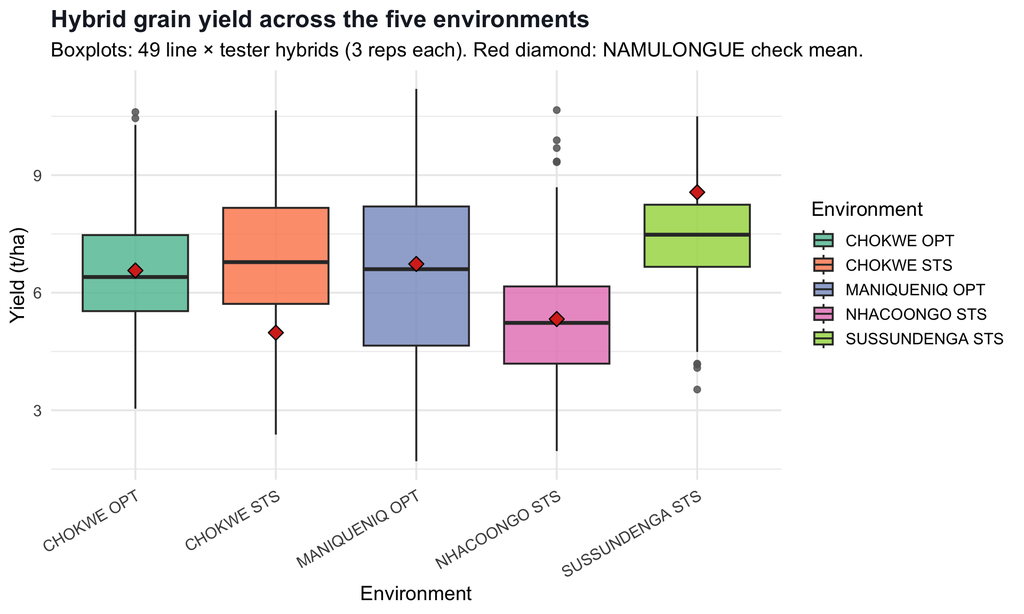

```r
check_means <- raw_data %>%
  filter(GEN == "0") %>%
  group_by(ENV) %>%
  summarize(check_mean = mean(yield), .groups = "drop")

ggplot(hybrids, aes(x = env, y = yield, fill = env)) +
  geom_boxplot(alpha = 0.85, outlier.color = "grey40") +
  geom_point(
    data = check_means,
    aes(x = ENV, y = check_mean),
    inherit.aes = FALSE,
    shape = 23, size = 3.5, fill = "#D7301F", color = "black"
  ) +
  scale_fill_brewer(palette = "Set2") +
  labs(
    title    = "Hybrid grain yield across the five environments",
    subtitle = "Boxplots: 49 line × tester hybrids (3 reps each). Red diamond: NAMULONGUE check mean.",
    x = "Environment",
    y = "Yield (t/ha)",
    fill = "Environment"
  ) +
  theme_minimal(base_size = 14) +
  theme(plot.title = element_text(face = "bold", color = "#1a202c"),
        axis.text.x = element_text(angle = 30, hjust = 1))
```

# 10 Fixed-Effects Calculations: Factorial Combining Ability

In a balanced factorial cross, GCA and SCA can be calculated arithmetically from family means. This provides a transparent foundation before using mixed models.

## 10.1 Arithmetic Formulas

Let $\bar{Y}_{p.}$ be the mean yield of all crosses involving female parent $p$, $\bar{Y}_{.q}$ the mean yield of all crosses involving male parent $q$, $\bar{Y}_{pq}$ the mean of the hybrid cross between female $p$ and male $q$, and $\bar{Y}_{..}$ the overall grand mean of all crosses in the factorial grid.

- **Grand Mean:** $\bar{Y}_{..} = \frac{1}{f \cdot m} \sum_{p} \sum_{q} \bar{Y}_{pq}$
- **GCA of Female Parent $p$:** $g_{F_p} = \bar{Y}_{p.} - \bar{Y}_{..}$
- **GCA of Male Parent $q$:** $g_{M_q} = \bar{Y}_{.q} - \bar{Y}_{..}$
- **SCA of Cross $pq$:** $s_{pq} = \bar{Y}_{pq} - \bar{Y}_{p.} - \bar{Y}_{.q} + \bar{Y}_{..}$

## 10.2 Direct R Arithmetic

We calculate these effects arithmetically from the entire hybrid dataset (all 5 environments pooled). The check is excluded.

```r
# 1. Family means over all environments and reps
family_means <- hybrids %>%
  group_by(female, male) %>%
  summarize(mean_yield = mean(yield), .groups = "drop")

# 2. Reshape to a 7x7 matrix (7 CIMMYT females in rows, 7 IIAM males in columns)
Y_matrix <- matrix(
  0, nrow = 7, ncol = 7,
  dimnames = list(levels(hybrids$female), levels(hybrids$male))
)
for (i in seq_len(nrow(family_means))) {
  Y_matrix[as.character(family_means$female[i]),
           as.character(family_means$male[i])] <- family_means$mean_yield[i]
}

# 3. Grand mean, marginal means
mu_hat       <- mean(Y_matrix)
female_means <- rowMeans(Y_matrix)
male_means   <- colMeans(Y_matrix)

# 4. Fixed GCA effects
gca_female_fixed <- female_means - mu_hat
gca_male_fixed   <- male_means - mu_hat

# 5. Fixed SCA effects
sca_fixed <- matrix(
  0, nrow = 7, ncol = 7,
  dimnames = list(levels(hybrids$female), levels(hybrids$male))
)
for (p in rownames(sca_fixed)) {
  for (q in colnames(sca_fixed)) {
    sca_fixed[p, q] <- Y_matrix[p, q] - gca_female_fixed[p] - gca_male_fixed[q] - mu_hat
  }
}

gca_female_df <- tibble(
  Female_Parent = names(gca_female_fixed),
  Mean_Yield    = round(female_means, 3),
  Estimated_GCA = round(gca_female_fixed, 4)
)
kable(gca_female_df, caption = "Estimated GCA Effects for Female Parents (CIMMYT CML Lines), Yield t/ha") %>%
  kable_styling(bootstrap_options = c("striped", "hover", "condensed"))
```

Estimated GCA Effects for Female Parents (CIMMYT CML Lines), Yield t/ha

| Female_Parent | Mean_Yield | Estimated_GCA |
| --- | --- | --- |
| CML364 | 6.428 | -0.0849 |
| CML366 | 6.376 | -0.1367 |
| CML434 | 6.808 | 0.2951 |
| CML435 | 6.315 | -0.1979 |
| CML439 | 6.201 | -0.3118 |
| CML530 | 7.091 | 0.5779 |
| CML532 | 6.371 | -0.1417 |

```r
gca_male_df <- tibble(
  Male_Parent   = names(gca_male_fixed),
  Mean_Yield    = round(male_means, 3),
  Estimated_GCA = round(gca_male_fixed, 4)
)
kable(gca_male_df, caption = "Estimated GCA Effects for Male Parents (IIAM Testers), Yield t/ha") %>%
  kable_styling(bootstrap_options = c("striped", "hover", "condensed"))
```

Estimated GCA Effects for Male Parents (IIAM Testers), Yield t/ha

| Male_Parent | Mean_Yield | Estimated_GCA |
| --- | --- | --- |
| EN17 | 6.488 | -0.0250 |
| EN20 | 6.625 | 0.1126 |
| EN21 | 6.479 | -0.0336 |
| EN25 | 6.570 | 0.0572 |
| EN31 | 6.435 | -0.0778 |
| EN32 | 6.353 | -0.1596 |
| EN64 | 6.639 | 0.1263 |

```r
kable(round(sca_fixed, 4), caption = "Arithmetic 7 × 7 Specific Combining Ability (SCA) grid, Yield t/ha") %>%
  kable_styling(bootstrap_options = c("striped", "hover", "bordered")) %>%
  row_spec(0, bold = TRUE, background = "#4a5568", color = "white")
```

Arithmetic 7 × 7 Specific Combining Ability (SCA) grid, Yield t/ha

|  | EN17 | EN20 | EN21 | EN25 | EN31 | EN32 | EN64 |
| --- | --- | --- | --- | --- | --- | --- | --- |
| CML364 | -0.2736 | 0.2015 | 0.6651 | -0.6385 | 0.2586 | -0.4349 | 0.2218 |
| CML366 | 0.6389 | -0.0400 | -0.1565 | 0.0387 | 0.4204 | -0.8038 | -0.0977 |
| CML434 | 0.0811 | 0.2982 | 0.0977 | -0.3305 | -0.0347 | 0.2017 | -0.3135 |
| CML435 | 0.5668 | 0.2046 | -0.1059 | -0.0554 | -0.0530 | -0.0146 | -0.5425 |
| CML439 | -0.3427 | -0.0235 | 0.1153 | 0.6332 | 0.4002 | -0.3020 | -0.4806 |
| CML530 | -0.1097 | -0.9832 | -0.1824 | 0.0388 | -0.1468 | 0.1963 | 1.1871 |
| CML532 | -0.5607 | 0.3424 | -0.4334 | 0.3137 | -0.8446 | 1.1573 | 0.0253 |

# 11 Mixed-Effects Calculations: Factorial Variance Components across Environments

In modern breeding, combining ability is analyzed with **Linear Mixed Models (LMMs)**: parents are treated as random samples from a reference population, and each combining-ability term gets a paired environment interaction so its G×E variance can be estimated separately (Isik et al., 2017). We fit the model with `sommer::mmer` on all five environments. Because female and male lines are distinct, **no matrix overlays are needed**.

## 11.1 Fitting the Mixed Model

- `env` enters as a **fixed effect** (different overall means across the five sites).
- `env:rep` captures replications (complete blocks) nested within environment.
- `env:rep:row` and `env:rep:col` capture the **field row and column** nested within each replication — the spatial correction across the 5 × 10 grid.
- `female`, `male`, `cross` are the random Female GCA, Male GCA, and SCA terms.
- `female:env`, `male:env`, `cross:env` are their G×E interactions.

```r
fit_gxe <- mmer(
  fixed  = yield ~ env,
  random = ~ female + male + cross +
             female:env + male:env + cross:env +
             env:rep + env:rep:row + env:rep:col,
  data    = hybrids,
  verbose = FALSE
)

var_comps <- summary(fit_gxe)$varcomp
kable(var_comps, caption = "Variance components — joint line × tester model across all 5 environments") %>%
  kable_styling(bootstrap_options = c("striped", "hover"))
```

Variance components — joint line × tester model across all 5 environments

|  | VarComp | VarCompSE | Zratio | Constraint |
| --- | --- | --- | --- | --- |
| female.yield-yield | 0.0362236 | 0.0605892 | 0.5978558 | Positive |
| male.yield-yield | 0.0000000 | 0.0252029 | 0.0000000 | Positive |
| cross.yield-yield | 0.0806985 | 0.0629241 | 1.2824723 | Positive |
| female:env.yield-yield | 0.1391360 | 0.0771015 | 1.8045821 | Positive |
| male:env.yield-yield | 0.0162365 | 0.0413295 | 0.3928544 | Positive |
| cross:env.yield-yield | 0.0000000 | 0.1152142 | 0.0000000 | Positive |
| env:rep.yield-yield | 0.3187163 | 0.1959835 | 1.6262403 | Positive |
| env:rep:row.yield-yield | 0.5579932 | 0.1303998 | 4.2790949 | Positive |
| env:rep:col.yield-yield | 0.0797589 | 0.0610383 | 1.3067037 | Positive |
| units.yield-yield | 2.2459838 | 0.1695684 | 13.2452996 | Positive |

## 11.2 Extracting GCA BLUPs

We extract the General Combining Ability predictions (BLUPs) for both parent sets.

```r
female_blups <- fit_gxe$U$female$yield
male_blups   <- fit_gxe$U$male$yield

female_blups_df <- tibble(
  CIMMYT_Female = gsub("female", "", names(female_blups)),
  GCA_BLUP      = round(as.numeric(female_blups), 4)
) %>%
  arrange(desc(GCA_BLUP))
kable(female_blups_df, caption = "Female GCA BLUPs (CIMMYT CML Lines), across-environment Yield t/ha") %>%
  kable_styling(bootstrap_options = c("striped", "hover", "condensed"))
```

Female GCA BLUPs (CIMMYT CML Lines), across-environment Yield t/ha

| CIMMYT_Female | GCA_BLUP |
| --- | --- |
| CML530 | 0.2144 |
| CML434 | 0.0995 |
| CML532 | -0.0351 |
| CML364 | -0.0428 |
| CML366 | -0.0545 |
| CML435 | -0.0854 |
| CML439 | -0.0962 |

```r
male_blups_df <- tibble(
  IIAM_Male = gsub("male", "", names(male_blups)),
  GCA_BLUP  = round(as.numeric(male_blups), 4)
) %>%
  arrange(desc(GCA_BLUP))
kable(male_blups_df, caption = "Male GCA BLUPs (IIAM Testers), across-environment Yield t/ha") %>%
  kable_styling(bootstrap_options = c("striped", "hover", "condensed"))
```

Male GCA BLUPs (IIAM Testers), across-environment Yield t/ha

| IIAM_Male | GCA_BLUP |
| --- | --- |
| EN17 | 0 |
| EN20 | 0 |
| EN21 | 0 |
| EN25 | 0 |
| EN31 | 0 |
| EN32 | 0 |
| EN64 | 0 |

## 11.3 Extracting SCA BLUPs

We extract the Specific Combining Ability predictions (dominance deviations) and format them into a $7 \times 7$ grid. Each cross BLUP is mapped back to its female/male cell via the pedigree key.

```r
cross_blups <- fit_gxe$U$cross$yield

# Pedigree key: cross string -> (female, male)
cross_key <- hybrids %>%
  distinct(cross, female, male) %>%
  mutate(cross = as.character(cross))

sca_df <- tibble(
  cross    = gsub("cross", "", names(cross_blups)),
  SCA_BLUP = as.numeric(cross_blups)
) %>%
  left_join(cross_key, by = "cross")

sca_matrix_blup <- matrix(
  0, nrow = 7, ncol = 7,
  dimnames = list(levels(hybrids$female), levels(hybrids$male))
)
for (i in seq_len(nrow(sca_df))) {
  sca_matrix_blup[as.character(sca_df$female[i]),
                  as.character(sca_df$male[i])] <- sca_df$SCA_BLUP[i]
}

kable(round(sca_matrix_blup, 4), caption = "7 × 7 Specific Combining Ability (SCA) BLUP grid, across-environment Yield t/ha") %>%
  kable_styling(bootstrap_options = c("striped", "hover", "bordered")) %>%
  row_spec(0, bold = TRUE, background = "#4a5568", color = "white")
```

7 × 7 Specific Combining Ability (SCA) BLUP grid, across-environment Yield t/ha

|  | EN17 | EN20 | EN21 | EN25 | EN31 | EN32 | EN64 |
| --- | --- | --- | --- | --- | --- | --- | --- |
| CML364 | -0.1320 | 0.0915 | 0.1900 | -0.1692 | 0.0470 | -0.1668 | 0.0443 |
| CML366 | 0.2085 | -0.0586 | -0.0371 | -0.0094 | 0.0714 | -0.2883 | -0.0078 |
| CML434 | 0.0652 | 0.1643 | 0.0075 | -0.0392 | 0.0078 | 0.0023 | 0.0138 |
| CML435 | 0.1179 | 0.0385 | -0.0785 | 0.0398 | -0.0442 | -0.0927 | -0.1709 |
| CML439 | -0.1446 | 0.0266 | 0.0128 | 0.1877 | 0.0815 | -0.1917 | -0.1864 |
| CML530 | -0.0051 | -0.2049 | 0.0180 | 0.0690 | -0.0174 | 0.1223 | 0.4957 |
| CML532 | -0.2111 | 0.1048 | -0.2052 | 0.1213 | -0.3137 | 0.3211 | 0.1048 |

# 12 Breeding Values (BV) and Genotypic Values (GV)

For hybrid selection we combine the BLUPs into two quantities:

1. **Breeding Value ($BV$):** the additive value of a cross, the sum of parent GCAs.
   $$BV_{pq} = g_{F_p} + g_{M_q}$$
2. **Genotypic Value ($GV$):** the total genetic value, $BV$ plus the SCA (dominance) deviation.
   $$GV_{pq} = g_{F_p} + g_{M_q} + s_{pq}$$

```r
genetic_values <- expand.grid(
  Female = levels(hybrids$female),
  Male   = levels(hybrids$male),
  stringsAsFactors = FALSE
) %>%
  mutate(
    GCA_Female         = map_dbl(Female, ~ female_blups_df$GCA_BLUP[female_blups_df$CIMMYT_Female == .x]),
    GCA_Male           = map_dbl(Male,   ~ male_blups_df$GCA_BLUP[male_blups_df$IIAM_Male == .x]),
    SCA                = map2_dbl(Female, Male, ~ sca_matrix_blup[.x, .y]),
    Breeding_Value_BV  = GCA_Female + GCA_Male,
    Genotypic_Value_GV = Breeding_Value_BV + SCA
  ) %>%
  arrange(desc(Genotypic_Value_GV))

kable(head(genetic_values, 15), caption = "Top 15 line × tester hybrids ranked by Genotypic Value (across-environment Yield t/ha)") %>%
  kable_styling(bootstrap_options = c("striped", "hover", "condensed"))
```

Top 15 line × tester hybrids ranked by Genotypic Value (across-environment Yield t/ha)

| Female | Male | GCA_Female | GCA_Male | SCA | Breeding_Value_BV | Genotypic_Value_GV |
| --- | --- | --- | --- | --- | --- | --- |
| CML530 | EN64 | 0.2144 | 0 | 0.4956545 | 0.2144 | 0.7100545 |
| CML530 | EN32 | 0.2144 | 0 | 0.1222942 | 0.2144 | 0.3366942 |
| CML532 | EN32 | -0.0351 | 0 | 0.3210700 | -0.0351 | 0.2859700 |
| CML530 | EN25 | 0.2144 | 0 | 0.0690471 | 0.2144 | 0.2834471 |
| CML434 | EN20 | 0.0995 | 0 | 0.1643452 | 0.0995 | 0.2638452 |
| CML530 | EN21 | 0.2144 | 0 | 0.0179677 | 0.2144 | 0.2323677 |
| CML530 | EN17 | 0.2144 | 0 | -0.0050826 | 0.2144 | 0.2093174 |
| CML530 | EN31 | 0.2144 | 0 | -0.0173892 | 0.2144 | 0.1970108 |
| CML434 | EN17 | 0.0995 | 0 | 0.0651795 | 0.0995 | 0.1646795 |
| CML366 | EN17 | -0.0545 | 0 | 0.2084955 | -0.0545 | 0.1539955 |
| CML364 | EN21 | -0.0428 | 0 | 0.1899811 | -0.0428 | 0.1471811 |
| CML434 | EN64 | 0.0995 | 0 | 0.0138266 | 0.0995 | 0.1133266 |
| CML434 | EN31 | 0.0995 | 0 | 0.0077615 | 0.0995 | 0.1072615 |
| CML434 | EN21 | 0.0995 | 0 | 0.0074986 | 0.0995 | 0.1069986 |
| CML434 | EN32 | 0.0995 | 0 | 0.0022672 | 0.0995 | 0.1017672 |

# 13 Across-Environment Heritability with G × E

We report **entry-mean (full-sib family-mean) heritability** — the accuracy with which cross rankings can be selected based on their mean across replicates and environments. With $e$ environments and $r$ reps per environment:

- **Genetic variance of cross means:** $\sigma^2_G = \sigma^2_{GCA_F} + \sigma^2_{GCA_M} + \sigma^2_{SCA}$
- **Additive component (entry mean):** $\sigma^2_{A,\bar{x}} = \sigma^2_{GCA_F} + \sigma^2_{GCA_M}$
- **Total G × E variance:** $\sigma^2_{GE} = \sigma^2_{GCA_F \times E} + \sigma^2_{GCA_M \times E} + \sigma^2_{SCA \times E}$
- **Entry-mean phenotypic variance:** $\sigma^2_{P,\bar{x}} = \sigma^2_G + \dfrac{\sigma^2_{GE}}{e} + \dfrac{\sigma^2_{\text{res}}}{e \cdot r}$
- **Narrow-sense entry-mean heritability:** $h^2_{\bar{x}} = \sigma^2_{A,\bar{x}} / \sigma^2_{P,\bar{x}}$
- **Broad-sense entry-mean heritability:** $H^2_{\bar{x}} = \sigma^2_G / \sigma^2_{P,\bar{x}}$

```r
# Pick variance components by regex on rowname. Interaction terms can appear as
# "female:env" or "env:female" depending on sommer's term ordering; match both.
# NOTE: every pattern is ANCHORED with ^. This is essential — an unanchored
# "male:env" would also match "female:env" (the word "female" ends in "male"),
# double-counting female GCA×E into the male term and inflating total G×E.
pick_vc <- function(vc, pat) {
  idx <- grep(pat, rownames(vc))
  if (length(idx) == 0) 0 else sum(vc[idx, "VarComp"])
}

var_gca_f_g <- pick_vc(var_comps, "^female\\.")
var_gca_m_g <- pick_vc(var_comps, "^male\\.")
var_sca_g   <- pick_vc(var_comps, "^cross\\.")
var_gca_f_e <- pick_vc(var_comps, "^female:env|^env:female")
var_gca_m_e <- pick_vc(var_comps, "^male:env|^env:male")
var_sca_e   <- pick_vc(var_comps, "^cross:env|^env:cross")
var_rep_g   <- pick_vc(var_comps, "^env:rep\\.")        # replication-in-env (literal dot excludes row/col)
var_row_g   <- pick_vc(var_comps, "^env:rep:row")       # field rows within replication
var_col_g   <- pick_vc(var_comps, "^env:rep:col")       # field columns within replication
var_res_g   <- pick_vc(var_comps, "^units\\.")

e_env <- n_distinct(hybrids$env)   # number of environments
r_rep <- 3                         # reps per environment

var_G_mean <- var_gca_f_g + var_gca_m_g + var_sca_g
var_A_mean <- var_gca_f_g + var_gca_m_g
var_GE     <- var_gca_f_e + var_gca_m_e + var_sca_e

# Replication, row, and column effects are design (nuisance) terms: they are
# removed by the experimental layout and do not enter the entry-mean phenotypic
# variance, exactly as `rep` does not. Modelling them only shrinks the residual.
var_phen_mean <- var_G_mean + var_GE / e_env + var_res_g / (e_env * r_rep)

h2_mean <- var_A_mean / var_phen_mean
H2_mean <- var_G_mean / var_phen_mean

gxe_results <- tibble(
  Parameter = c(
    "GCA Female variance",
    "GCA Male variance",
    "SCA variance",
    "GCA_F × Env variance",
    "GCA_M × Env variance",
    "SCA × Env variance",
    "Total G × E variance",
    "Replication variance (env:rep)",
    "Field-row variance (env:rep:row)",
    "Field-column variance (env:rep:col)",
    "Residual variance",
    "Genetic variance of cross means (Vg)",
    "Entry-mean phenotypic variance (Vp_mean)",
    "Narrow-sense h² (entry mean across envs)",
    "Broad-sense H² (entry mean across envs)"
  ),
  Value = round(c(
    var_gca_f_g, var_gca_m_g, var_sca_g,
    var_gca_f_e, var_gca_m_e, var_sca_e,
    var_GE, var_rep_g, var_row_g, var_col_g, var_res_g,
    var_G_mean, var_phen_mean,
    h2_mean, H2_mean
  ), 4)
)

kable(gxe_results, caption = "Genetic variances, G × E, and entry-mean heritabilities — joint five-environment model") %>%
  kable_styling(bootstrap_options = c("striped", "hover", "condensed"))
```

Genetic variances, G × E, and entry-mean heritabilities — joint five-environment model

| Parameter | Value |
| --- | --- |
| GCA Female variance | 0.0362 |
| GCA Male variance | 0.0000 |
| SCA variance | 0.0807 |
| GCA_F × Env variance | 0.1391 |
| GCA_M × Env variance | 0.0162 |
| SCA × Env variance | 0.0000 |
| Total G × E variance | 0.1554 |
| Replication variance (env:rep) | 0.3187 |
| Field-row variance (env:rep:row) | 0.5580 |
| Field-column variance (env:rep:col) | 0.0798 |
| Residual variance | 2.2460 |
| Genetic variance of cross means (Vg) | 0.1169 |
| Entry-mean phenotypic variance (Vp_mean) | 0.2977 |
| Narrow-sense h² (entry mean across envs) | 0.1217 |
| Broad-sense H² (entry mean across envs) | 0.3927 |

> [!TIP] * If $\sigma^2_{GE}$ is a substantial fraction of $\sigma^2_{GCA_F} + \sigma^2_{GCA_M} + \sigma^2_{SCA}$, the ranking of parents and crosses is **environment-dependent** — selection should be done within target environments (e.g., a Chokwe stress site) rather than on across-environment means. * Both heritabilities are bounded in $[0, 1]$, as expected from a properly specified entry-mean form.

**Important**

**Why these estimates look the way they do — and what is real vs. fixable.**

- **Male (tester) GCA and SCA×E estimate to ~0, and this is correct.** A fixed-effects ANOVA gives male `MS = 1.14`, *below* the residual `MS = 2.96` (`p = 0.89`), so the unconstrained REML variance is negative and is pinned at 0 (`Z ≈ 0`); the SCA×environment term (`cross:env`) likewise estimates to 0. The SCA (cross) variance is small (≈ 0.08, ANOVA `p = 0.07`). The real signal is **female (line) GCA** (ANOVA `p = 0.002`) and its **environment interaction** (`female:env` is the largest G×E variance, ≈ 0.14): the seven CIMMYT donor lines differ and re-rank across sites; the seven local testers do not.
- **Narrow-sense $h^2_{\bar{x}}$ is low (~0.12).** Additive variance is small and one-sided (males add nothing), and $\sigma^2_{GCA_F \times E}$ (≈ 0.14) is *larger* than $\sigma^2_{GCA_F}$ (≈ 0.04) — the lines re-rank strongly across five climatically distinct sites (NHACOONGO mean 5.25 vs. SUSSUNDENGA 7.41 t/ha). Across-environment narrow-sense heritability *should* be low when G×E dominates the additive signal.
- **The field row/column spatial terms are modelled (`env:rep:row`, `env:rep:col`), which is why $H^2_{\bar{x}}$ is realistic.** The field **row** carries a **highly significant** variance (≈ 0.56, `Z ≈ 4.3`) and the column a smaller one (≈ 0.08, `Z ≈ 1.3`); together they absorb genuine field gradient across the 5 × 10 grid that would otherwise inflate the residual. Compared with a plain RCBD (rep only) the residual drops ~22% (2.86 → 2.25) and broad-sense $H^2_{\bar{x}}$ rises from ≈ 0.30 to ≈ **0.39**. These coordinates are Stelio’s real planting positions (5 × 10 serpentine), so this is a legitimate spatial correction, not an arbitrary split.

# 14 Step-by-Step Checklist for Stelio

# References

Comstock, R. E., & Robinson, H. F. (1948). The components of genetic variance in populations of biparental progenies and their use in estimating the average degree of dominance. *Biometrics*, *4*(4), 254–266. https://doi.org/10.2307/3001412

Isik, F., Holland, J., & Maltecca, C. (2017). *Genetic data analysis for plant and animal breeding*. Springer International Publishing. https://doi.org/10.1007/978-3-319-55177-7

Patterson, H. D., & Williams, E. R. (1976). A new class of resolvable incomplete block designs. *Biometrika*, *63*(1), 83–92. https://doi.org/10.1093/biomet/63.1.83